# n19 - Single Facility Network Location Problem

[figure not shown]

*Transport Analytics Training Series - Last Revision: October 2022*

## Single Facility Location Problems

```python
!pip install pulp
```

```
     |████████████████████████████████| 14.3 MB 2.5 MB/s eta 0:00:01
```

```python
import numpy as np
import matplotlib
import matplotlib.pyplot as plt
import seaborn as sns; sns.set()
from sklearn.datasets import make_blobs

%matplotlib inline

plot_size   = 14
plot_width  = 5
plot_height = 5

params = {'legend.fontsize': 'large',
          'figure.figsize': (plot_width,plot_height),
          'axes.labelsize': plot_size,
          'axes.titlesize': plot_size,
          'xtick.labelsize': plot_size*0.75,
          'ytick.labelsize': plot_size*0.75,
          'axes.titlepad': 25}
plt.rcParams.update(params)
```

```python
num_customer = 40
num_facility = 5
```

We set here the number of customers and facilities that will be used by the data generators and later in the model.

```python
center_box = (100, 200)

cust_coord, _ = make_blobs(n_samples=num_customer,
                           centers=2,
                           cluster_std=20,
                           center_box=center_box,
                           random_state = 2)
```

We are again using `make_blobs` to generate a random set of customers.

You might notice that we are saving predicted cluster indices (which we don't need) to a variable named `_`. This is a real variable name, which is commonly used whenever we want to disregard a certain value.

```python
facil_coord, _ = make_blobs(n_samples=num_facility,
                            centers=1,
                            cluster_std=30,
                            center_box=center_box,
                            random_state = 50)

facil_coord
```

```
array([[110.99138668,  82.98394341],
       [153.25029374, 148.67412191],
       [126.04608814, 154.9163425 ],
       [130.83231184,  78.87089589],
       [191.81854821, 108.50634614]])
```

To solve the facility location problem, we also need to provide a set of candidate locations. We use `make_blobs` again for this.

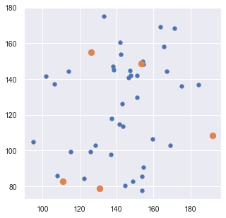

```python
plt.scatter(cust_coord[:, 0], cust_coord[:, 1], s=plot_size*2, cmap='viridis');

plt.scatter(facil_coord[:, 0], facil_coord[:, 1], s=plot_size*5, cmap='viridis');
```

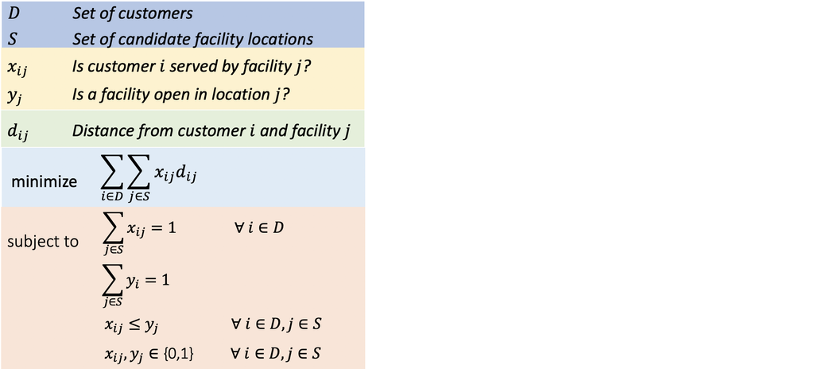

```python
from pulp import *

prob = LpProblem('prob', LpMinimize)
```

We are back again in using `PuLP`.

```python
from scipy.spatial import distance

dist_matrix = distance.cdist(facil_coord, facil_coord, 'euclidean').round(2)

dist_matrix
```

```
array([[ 0.  , 78.11, 73.49, 20.26, 84.76],
       [78.11,  0.  , 27.91, 73.31, 55.69],
       [73.49, 27.91,  0.  , 76.2 , 80.5 ],
       [20.26, 73.31, 76.2 ,  0.  , 67.81],
       [84.76, 55.69, 80.5 , 67.81,  0.  ]])
```

We are going to use the `distance.cdist()` command to determine the euclidean distances between our sets of customers and facility coordinates.

In a real application, we will instead by using a pathfinder, or a travel time database to obtain realistic values that reflect the structure of the network.

The cell above calculates a distance matrix between all facilitiy locations. You might also notice that we are also using the `round()` function, as the original values will have a very large number of decimals, and would not render well when printed out.

```python
dist_matrix = distance.cdist(cust_coord, facil_coord, 'euclidean')

dist_matrix.shape
```

```
(40, 5)
```

With the above command we have now calculated the distance matrix between the set of customers and facilities.

The `shape` property is used check the size of the matrix. This appears to be 40 x 5, as expected.

```python
S = [('S'+str(i+1)) for i in range(num_facility)]
D = [('C'+str(i+1)) for i in range(num_customer)]
```

With the above in-line for loop, we are generating the indices for each customer and facility location element, to be saved in `D` and `S`, respectively.

You can check out their contents int he cell below:

```python
print(f'The S array contains the following: \n{S}\n')

print(f'While D, contains: \n{D}')
```

```
The S array contains the following:
['S1', 'S2', 'S3', 'S4', 'S5']

While D, contains:
['C1', 'C2', 'C3', 'C4', 'C5', 'C6', 'C7', 'C8', 'C9', 'C10', 'C11', 'C12', 'C13', 'C14', 'C15', 'C16', 'C17', 'C18', 'C19', 'C20', 'C21', 'C22', 'C23', 'C24', 'C25', 'C26', 'C27', 'C28', 'C29', 'C30', 'C31', 'C32', 'C33', 'C34', 'C35', 'C36', 'C37', 'C38', 'C39', 'C40']
```

```python
d = {customer:{facility: round(dist_matrix[i][j],2) for j,facility in enumerate(S)} for i,customer in enumerate(D)}
```

With another inline for loop (a nested one, in this case), we have generated a dictionary of distances between customers *i* and facilities *j*. For visualisation purposes, we have rounded again the values to two decimals.

```python
d
```

```
{'C1': {'S1': 104.73, 'S2': 26.92, 'S3': 47.4, 'S4': 98.4, 'S5': 63.35},
 'C2': {'S1': 83.04, 'S2': 25.2, 'S3': 52.49, 'S4': 72.12, 'S5': 32.17},
 'C3': {'S1': 53.66, 'S2': 42.74, 'S3': 58.85, 'S4': 39.57, 'S5': 32.6},
 'C4': {'S1': 43.83, 'S2': 34.55, 'S3': 38.59, 'S4': 39.68, 'S5': 55.31},
 'C5': {'S1': 69.77, 'S2': 15.1, 'S3': 14.4, 'S4': 68.75, 'S5': 66.12},
 'C6': {'S1': 78.67, 'S2': 1.4, 'S3': 29.31, 'S4': 73.52, 'S5': 54.57},
 'C7': {'S1': 53.82, 'S2': 24.71, 'S3': 33.55, 'S4': 48.82, 'S5': 51.69},
 'C8': {'S1': 33.55, 'S2': 69.01, 'S3': 76.91, 'S4': 13.67, 'S5': 55.18},
 'C9': {'S1': 90.97, 'S2': 33.25, 'S3': 61.02, 'S4': 78.86, 'S5': 29.29},
 'C10': {'S1': 4.28, 'S2': 77.66, 'S3': 71.54, 'S4': 24.11, 'S5': 87.11},
 'C11': {'S1': 11.54, 'S2': 71.27, 'S3': 70.6, 'S4': 10.06, 'S5': 73.44},
 'C12': {'S1': 44.62, 'S2': 36.53, 'S3': 45.04, 'S4': 36.85, 'S5': 48.47},
 'C13': {'S1': 61.2, 'S2': 48.4, 'S3': 67.4, 'S4': 44.97, 'S5': 23.63},
 'C14': {'S1': 83.34, 'S2': 16.31, 'S3': 16.77, 'S4': 82.26, 'S5': 71.99},
 'C15': {'S1': 29.81, 'S2': 53.39, 'S3': 58.06, 'S4': 19.92, 'S5': 56.01},
 'C16': {'S1': 17.06, 'S2': 62.17, 'S3': 56.45, 'S4': 25.92, 'S5': 77.17},
 'C17': {'S1': 37.74, 'S2': 66.01, 'S3': 75.58, 'S4': 18.33, 'S5': 50.16},
 'C18': {'S1': 94.83, 'S2': 33.39, 'S3': 21.46, 'S4': 96.38, 'S5': 88.95},
 'C19': {'S1': 26.52, 'S2': 52.08, 'S3': 52.21, 'S4': 24.0, 'S5': 63.44},
 'C20': {'S1': 44.06, 'S2': 58.02, 'S3': 70.22, 'S4': 26.34, 'S5': 41.47},
 'C21': {'S1': 100.93, 'S2': 22.91, 'S3': 40.18, 'S4': 96.01, 'S5': 66.83},
 'C22': {'S1': 71.39, 'S2': 7.0, 'S3': 28.26, 'S4': 66.31, 'S5': 52.66},
 'C23': {'S1': 77.33, 'S2': 12.07, 'S3': 16.27, 'S4': 75.7, 'S5': 67.06},
 'C24': {'S1': 61.58, 'S2': 19.02, 'S3': 35.42, 'S4': 54.77, 'S5': 46.02},
 'C25': {'S1': 69.41, 'S2': 8.81, 'S3': 24.98, 'S4': 65.32, 'S5': 55.61},
 'C26': {'S1': 68.06, 'S2': 15.25, 'S3': 15.65, 'S4': 66.84, 'S5': 64.87},
 'C27': {'S1': 20.28, 'S2': 73.34, 'S3': 76.23, 'S4': 0.03, 'S5': 67.81},
 'C28': {'S1': 22.32, 'S2': 56.23, 'S3': 55.45, 'S4': 21.14, 'S5': 66.4},
 'C29': {'S1': 42.99, 'S2': 70.99, 'S3': 82.02, 'S4': 22.86, 'S5': 49.05},
 'C30': {'S1': 59.44, 'S2': 51.94, 'S3': 27.63, 'S4': 69.22, 'S5': 95.97},
 'C31': {'S1': 67.96, 'S2': 10.25, 'S3': 24.87, 'S4': 63.98, 'S5': 55.63},
 'C32': {'S1': 79.77, 'S2': 1.66, 'S3': 28.55, 'S4': 74.91, 'S5': 56.06},
 'C33': {'S1': 54.44, 'S2': 48.39, 'S3': 26.56, 'S4': 63.32, 'S5': 90.27},
 'C34': {'S1': 71.76, 'S2': 7.04, 'S3': 23.54, 'S4': 68.02, 'S5': 57.45},
 'C35': {'S1': 83.32, 'S2': 14.56, 'S3': 42.45, 'S4': 75.02, 'S5': 43.6},
 'C36': {'S1': 42.73, 'S2': 62.97, 'S3': 74.5, 'S4': 23.81, 'S5': 44.47},
 'C37': {'S1': 92.89, 'S2': 15.5, 'S3': 39.55, 'S4': 86.59, 'S5': 56.29},
 'C38': {'S1': 43.98, 'S2': 35.94, 'S3': 43.01, 'S4': 37.4, 'S5': 50.79},
 'C39': {'S1': 61.56, 'S2': 39.32, 'S3': 15.83, 'S4': 67.67, 'S5': 85.58},
 'C40': {'S1': 27.14, 'S2': 72.97, 'S3': 58.96, 'S4': 44.34, 'S5': 96.98}}
```

```python
x = LpVariable.dicts('x', (D,S), lowBound = 0, upBound = 1, cat = LpInteger)
y = LpVariable.dicts('y', S, lowBound = 0, upBound = 1, cat = LpInteger)
```

With the above we have created our sets of decision variables, both defined as Booleans (integers with values between 0 and 1).

```python
prob += lpSum([lpSum([x[i][j]*d[i][j] for j in S]) for i in D])
```

The above expression defines our objective, which minimises the product of distances with the decision variables that indicate whether a facility and customer are connected.

```python
for i in D:
    prob += lpSum([x[i][j] for j in S]) == 1
```

Contraint 1: Ensure that only one facility serves each customer.

```python
prob += lpSum([y[j] for j in S]) == 1
```

Contraint 2: Ensure that only one facility is open.

```python
for i in D:
    for j in S:
        prob += x[i][j] <= y[j]
```

Contraint 3: A facility will not serve a customer if it has not been opened.

```python
status = prob.solve()

print(f'STATUS\n{LpStatus[status]}\n')
```

[output not shown]

```python
for j,facility in enumerate(S):
    if y[facility].varValue == 1:
        chosen_facil = j
        print(f'We will be opening a facility in {facility}')
```

```
We will be opening a facility in S2
```

With the above loop, we are iterating through all decision variables in y to establish whether a facility has been opened.

```python
tran_cost = 0;

for j,facility in enumerate(S):
    for i,customer in enumerate(D):
        if x[customer][facility].varValue == 1:
            tran_cost += dist_matrix[i][j]

print(f'The objective value of the problem (total transportation cost) is {value(prob.objective)}');
```

```
The objective value of the problem (total transportation cost) is 1494.27
```

## Summary

[output not shown]

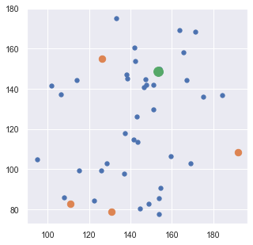

```python
plt.scatter(cust_coord[:, 0],
            cust_coord[:, 1],
            s=plot_size*2,
            cmap='viridis');

plt.scatter(facil_coord[:, 0],
            facil_coord[:, 1],
            s=plot_size*5,
            cmap='viridis');

plt.scatter(facil_coord[chosen_facil, 0],
            facil_coord[chosen_facil, 1],
            s=plot_size*10,
            cmap='viridis');
```

In green color, the above graph demonstrates the location of the chosen facility.